# 跟着iMeta学做图｜群落微生物与环境因子相关性分析

农心生信工作室

2022-10-30

本教程相关代码已经上传至 https://github.com/iMetaScience/iMetaPlot/tree/main/221030RDA 如果你使用本代码，请引用： Zeyu Zhang. 2022. Tomato microbiome under long-term organic and conventional farming. iMeta 1: e48. https://onlinelibrary.wiley.com/doi/full/10.1002/imt2.48

**代码编写及注释：农心生信工作室**

中农李季组冗余分析（Redundancy analysis，RDA）是微生物生态领域常用的分析手段，可用于研究微生物群落结构对环境变化的响应，相信此类专业的老师和同学一定不陌生，我们挑选了iMeta期刊上发表的来自中国农业大学李季老师团队的论文[Tomato Microbiome under Long-term Organic and Conventional Farming](https://onlinelibrary.wiley.com/doi/full/10.1002/imt2.48)，该研究对番茄内生细菌群落的变化及其影响因素进行了分析，论文的Figure 4 F中涉及RDA分析，Figure 4如下：

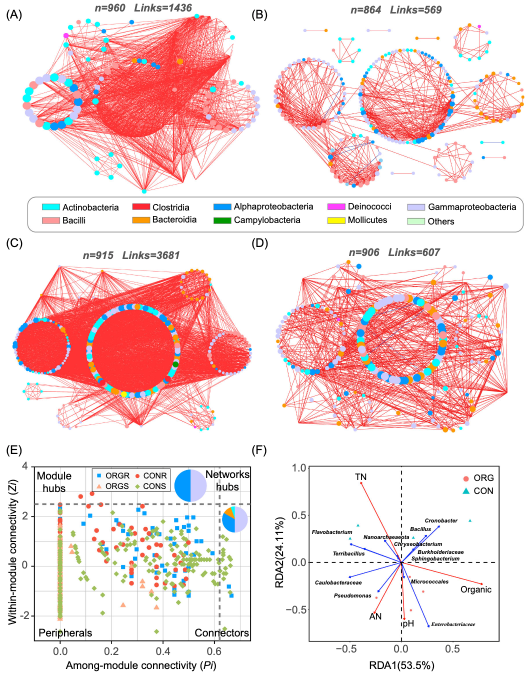

本文我们利用R语言重现该图，数据均随机生成，大家直接复制粘贴即可运行

### R包检测和安装

```r
# 检查微生物群落分析包vegan，如没有则安装
if (!require("vegan"))
  install.packages("vegan")
# 检查ggplot2拓展包用图中文字的标注
if (!require("ggrepel"))
  install.packages("ggrepel")

# 加载包
library(vegan)
library(ggrepel)
```

### 生成测试数据

2. 设定随机种子并开始随机生成响应变量数据，共生成80条样本，数值为0-10之间的随机数

```r
set.seed(42) #设置随机种子
data1 <- data.frame(TN = runif(80, 0, 10),
                                        PH = runif(80, 0, 10),
                                        Organic=runif(80, 0, 10),
                                        AN=runif(80, 0, 10),
                    Enterobacteriaceae=runif(80, 0, 10),
                    Pseudomonas=runif(80, 0, 10),
                    Caulobacteraceae=runif(80, 0, 10),
                    Terribacillus=runif(80, 0, 10),
                    Sphingobacteriunm=runif(80, 0, 10),
                    Burkholderiaceae=runif(80, 0, 10),
                    Micrococcales=runif(80, 0, 10),
                    Chryseobacterium=runif(80, 0, 10),
                    Cronobacter=runif(80, 0, 10),
                    Bacillus=runif(80, 0, 10),
                    Nanoarchaeaeota=runif(80, 0, 10),
                    Flavobacterium=runif(80, 0, 10))
# 可选：从文件中读取
# write.table(data1, file="data1.txt", sep="\t", quote = F, row.names = T, col.names = T)
# data1 <- read.table("data1.txt")
data1  # 查看data1数据框
```

| TN | PH | Organic | AN | Enterobacteriaceae | Pseudomonas | Caulobacteraceae | Terribacillus | Sphingobacteriunm | Burkholderiaceae | Micrococcales | Chryseobacterium | Cronobacter | Bacillus | Nanoarchaeaeota | Flavobacterium |
| --- | --- | --- | --- | --- | --- | --- | --- | --- | --- | --- | --- | --- | --- | --- | --- |
| 9.14806043 | 5.816040025 | 9.3482295 | 0.6763682 | 4.30333221 | 0.22700011 | 2.32934385 | 7.950512362 | 3.1398168 | 1.97991927 | 9.09047515 | 9.1275158 | 4.10754823 | 9.4491319 | 7.21638614 | 4.0188039 |
| 9.37075413 | 1.579052082 | 5.5049408 | 5.6143796 | 3.93776922 | 5.13239528 | 5.77048209 | 2.056735931 | 1.1581714 | 6.25107899 | 8.99924811 | 7.5530192 | 6.63253142 | 3.4671377 | 9.02706995 | 4.3221420 |
| 2.86139535 | 3.590283059 | 6.0176624 | 0.7072189 | 1.41908895 | 6.30726152 | 8.40877033 | 0.481933230 | 5.7500407 | 1.38182841 | 1.92349254 | 6.3099992 | 0.27117778 | 3.6934622 | 5.35714265 | 6.6360441 |
| 8.30447626 | 6.456318784 | 1.9699449 | 2.1139194 | 2.79806696 | 4.18771624 | 1.32203777 | 0.388159312 | 8.3137192 | 3.73078521 | 5.32290264 | 7.9442065 | 8.15928965 | 6.2414874 | 3.48539336 | 1.8236933 |
| 6.41745519 | 7.758233626 | 5.3523661 | 5.4962041 | 5.64822223 | 8.79265945 | 8.95891190 | 2.845741299 | 5.2033976 | 3.14089833 | 5.22124741 | 9.2354646 | 0.75042779 | 7.2740583 | 8.33293378 | 8.3833876 |
| 5.19095949 | 5.636468416 | 1.7955574 | 4.8198145 | 9.35139505 | 1.07987073 | 4.50137341 | 3.488098325 | 6.9401103 | 8.15184900 | 1.60335731 | 1.6446881 | 9.00965292 | 1.9792811 | 7.90328991 | 9.1737298 |
| 7.36588315 | 2.337033986 | 4.5188649 | 1.5946985 | 3.58400145 | 9.80278696 | 8.94142538 | 7.374533254 | 4.9990399 | 3.68318097 | 5.19567018 | 1.9288394 | 0.70827235 | 5.8871520 | 5.31409060 | 7.9830106 |
| 1.34666597 | 0.899805163 | 3.1705335 | 1.4957900 | 8.42007181 | 2.64966631 | 2.48545181 | 2.516635812 | 3.5416040 | 4.39644126 | 2.24503509 | 0.9764267 | 1.91123383 | 8.4289717 | 7.78718973 | 5.0305628 |
| 6.56992290 | 0.856120649 | 1.1617467 | 4.9927288 | 7.22409214 | 0.84277523 | 0.83695294 | 5.174370031 | 9.6480416 | 4.39058027 | 2.81511990 | 8.2910940 | 7.76929248 | 9.9937903 | 0.58358947 | 2.5445950 |
| 7.05064784 | 3.052183695 | 1.8610216 | 9.4056488 | 7.50735989 | 3.85907176 | 0.48641075 | 7.594447227 | 9.2226125 | 6.01828286 | 5.03687580 | 8.0586396 | 2.03133504 | 0.1143825 | 4.58110426 | 6.6724544 |

[output cut: 70 more lines]

3. 对响应变量进行hellinger标准化，

```r
data1 <- decostand(data1, method = "hellinger")
```

4. 随机生成解释变量数据，data2和data1行数必须相等，前面40条数据属于CON处理，后面40条数据属于ORG处理

```r
data2 = data.frame(group = c(rep("CON1",10),rep("CON2",10), rep("CON3",10), rep("CON4",10), rep("ORG1",10),rep("ORG2",10), rep("ORG3",10), rep("ORG4",10)))

# 可选：从文件中读取
# write.table(data2, file="data2.txt", sep="\t", quote = F, row.names = T, col.names = T)
# data2 <- read.table("data2.txt")
```

### RDA分析和排序图绘制

5. RDA分析本身实现很简单，一行代码即可

```r
res <- rda(data1 ~ . , data2)
```

6. 下面进行一些画图前的数据处理，注意这里使用factor函数的levels参数只是为了改变ggplot2中legend的顺序从而和原图保持一致，默认强况下画出的图ORG在CON下方

```r
centroids <- as.data.frame(res$CCA$centroids[,c(1,2)]) #取RDA1，RDA2轴进行可视化
centroids$group <- factor(c(rep('CON',4),rep('ORG',4)), levels = c('ORG', 'CON')) # 给centroids数据框增加一列用于区分形状并上色
rda.v <- as.data.frame(res$CCA$v[,c(1,2)])
rda.v$name = row.names(rda.v) #提取响应变量名称用于在图中展示标签
```

制定画图中箭头的数据，并给出颜色

```r
arrow_data <- data.frame(x=rda.v[,1], y = rda.v[,2], x_end=0, y_end=0, name=rda.v[,3], col='blue')
arrow_data[arrow_data$name %in% c('PH', 'TN', 'Organic', 'AN'), ]$col <- 'red'
```

7. 开始画图，先把解释变量的point画出

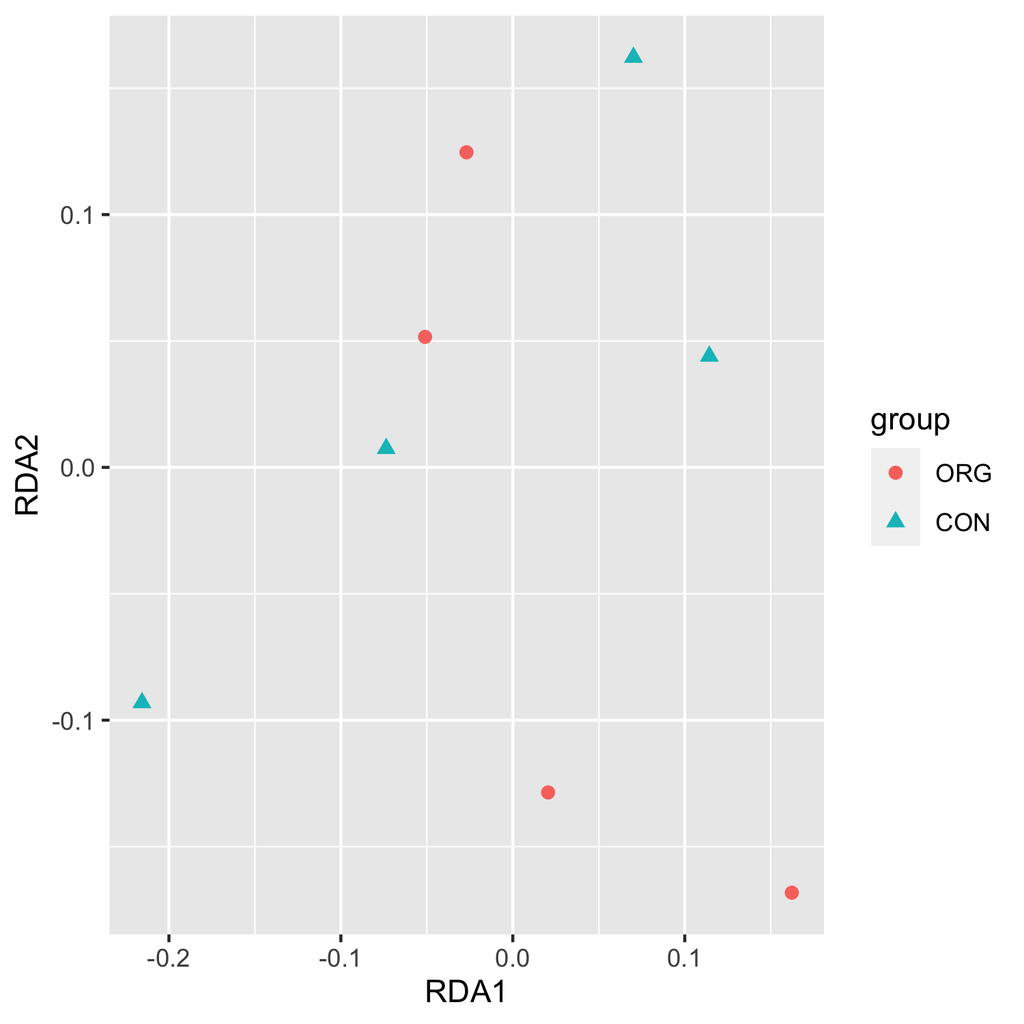

```r
p1 <- ggplot(data = centroids) +
        geom_point(size=2, aes(x = RDA1,y=RDA2,color=group, shape=group))
p1
```

8. 在p1的基础上再把响应变量的位置标出，注意标签斜体

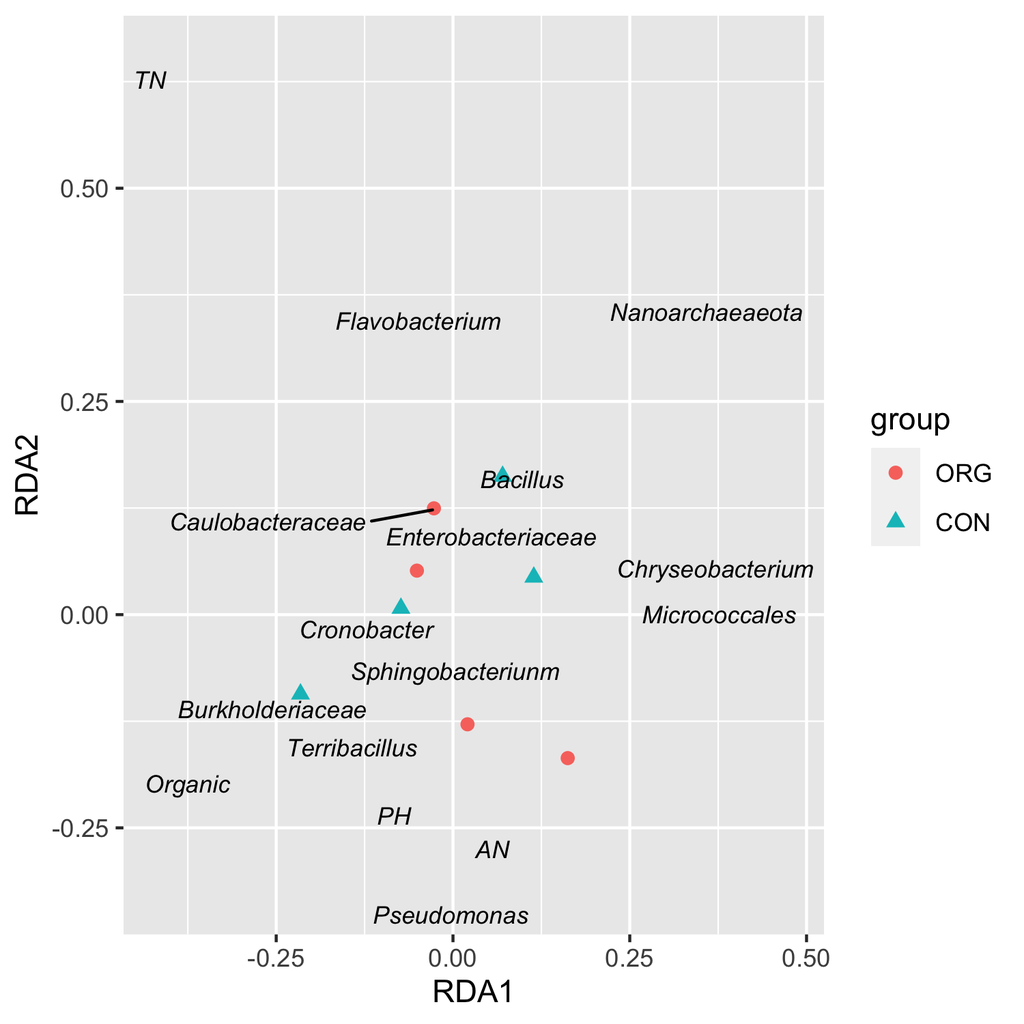

```r
p2 <- p1 + ggrepel::geom_text_repel(data = arrow_data, aes(x,y,label=name),
                              size=3, fontface="italic")
p2
```

9. 进一步画出响应变量的箭头

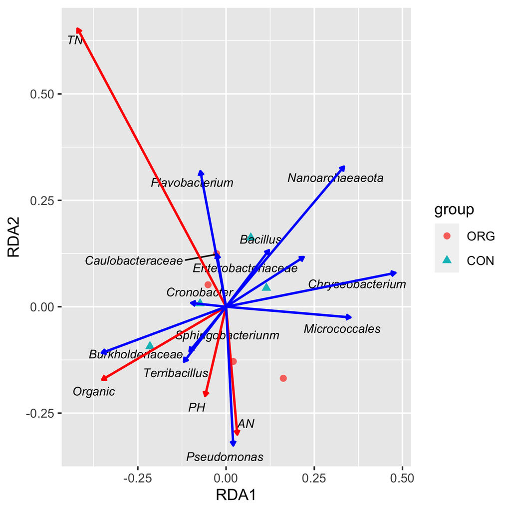

```r
p3 <- p2 + geom_segment(data = arrow_data,
               aes(x=0, y=0, xend=x, yend=y),
               arrow = arrow(length = unit(0.05,"inches")), color = arrow_data$col, size=.8)
p3
```

10. 这是图已经基本成型，需要再完善一些细节。画出虚线

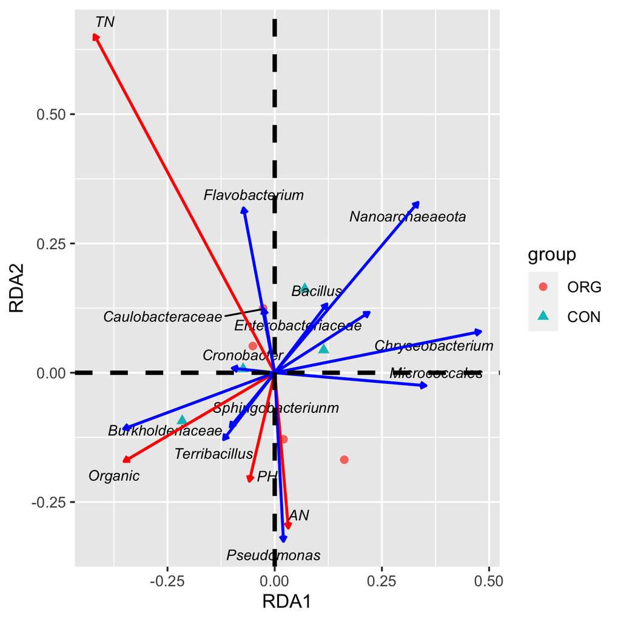

```r
p4 <- p3 + geom_hline(yintercept = 0, linetype = "dashed", size=1.2) +
  geom_vline(xintercept = 0,linetype = "dashed", size=1.2)
p4
```

11. 去掉图例标题并改变图例位置

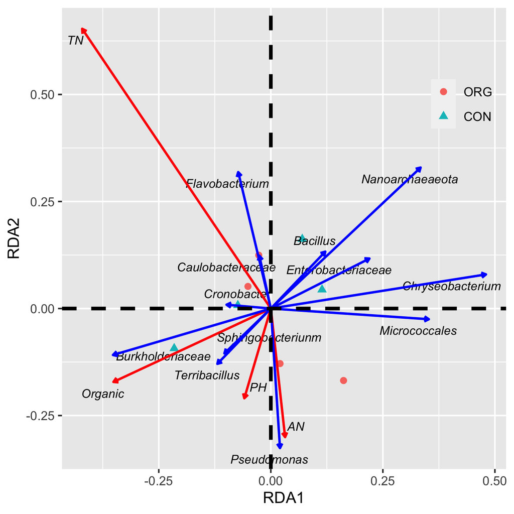

```r
p5 <- p4 + theme(legend.title = element_blank(), legend.position = c(0.9,0.8), legend.background = element_blank())
p5
```

12. 距离成功只差一步啦，改变背景颜色，并修改横纵坐标轴

```r
p6 <- p5 + theme(panel.grid.major = element_blank(), panel.grid.minor = element_blank(),
            panel.background = element_blank(), axis.line = element_line(colour = "black"), panel.border = element_rect(colour = "black", fill=NA, size=1)) + labs(x = 'RDA1(53.5%)',y = 'RDA2(24.11%)')
ggsave('RDA_plot.pdf', p6, height = 10, width = 8)  # 保存图片并设置宽和高
```

### 附.完整代码

```r
if (!require("vegan"))
  install.packages("vegan")
if (!require("ggrepel"))
  install.packages("ggrepel")

library(vegan)
library(ggrepel)

set.seed(42) #设置随机种子
data1 <- data.frame(TN = runif(80, 0, 10),
                                        PH = runif(80, 0, 10),
                                        Organic=runif(80, 0, 10),
                                        AN=runif(80, 0, 10),
                    Enterobacteriaceae=runif(80, 0, 10),
                    Pseudomonas=runif(80, 0, 10),
                    Caulobacteraceae=runif(80, 0, 10),
                    Terribacillus=runif(80, 0, 10),
                    Sphingobacteriunm=runif(80, 0, 10),
                    Burkholderiaceae=runif(80, 0, 10),
                    Micrococcales=runif(80, 0, 10),
                    Chryseobacterium=runif(80, 0, 10),
                    Cronobacter=runif(80, 0, 10),
                    Bacillus=runif(80, 0, 10),
                    Nanoarchaeaeota=runif(80, 0, 10),
                    Flavobacterium=runif(80, 0, 10))

data1 <- decostand(data1, method = "hellinger")
data2 = data.frame(group = c(rep("CON1",10),rep("CON2",10), rep("CON3",10), rep("CON4",10), rep("ORG1",10),rep("ORG2",10), rep("ORG3",10), rep("ORG4",10)))
res <- rda(data1 ~ . , data2)

centroids <- as.data.frame(res$CCA$centroids[,c(1,2)]) #取RDA1，RDA2轴进行可视化
centroids$group <- factor(c(rep('CON',4),rep('ORG',4)), levels = c('ORG', 'CON')) # 给centroids数据框增加一列用于区分形状并上色
rda.v <- as.data.frame(res$CCA$v[,c(1,2)])
rda.v$name = row.names(rda.v) #提取响应变量名称用于在图中展示标签
arrow_data <- data.frame(x=rda.v[,1], y = rda.v[,2], x_end=0, y_end=0, name=rda.v[,3], col='blue')
arrow_data[arrow_data$name %in% c('PH', 'TN', 'Organic', 'AN'), ]$col <- 'red'
p1 <- ggplot(data = centroids) +
        geom_point(size=2, aes(x = RDA1,y=RDA2,color=group, shape=group))
p2 <- p1 + ggrepel::geom_text_repel(data = arrow_data, aes(x,y,label=name),
                              size=3, fontface="italic")
p3 <- p2 + geom_segment(data = arrow_data,
               aes(x=0, y=0, xend=x, yend=y),
               arrow = arrow(length = unit(0.05,"inches")), color = arrow_data$col, size=.8)
p4 <- p3 + geom_hline(yintercept = 0, linetype = "dashed", size=1.2) +
  geom_vline(xintercept = 0,linetype = "dashed", size=1.2)
p5 <- p4 + theme(legend.title = element_blank(), legend.position = c(0.9,0.8), legend.background = element_blank())
p6 <- p5 + theme(panel.grid.major = element_blank(), panel.grid.minor = element_blank(),
            panel.background = element_blank(), axis.line = element_line(colour = "black"), panel.border = element_rect(colour = "black", fill=NA, size=1)) + labs(x = 'RDA1(53.5%)',y = 'RDA2(24.11%)')
ggsave('RDA_plot.pdf', p6, height = 10, width = 8)
```

RDA的绘图就完成了。大家多多动手操作，很快就可以学会！RDA分析绘图不难，但是理解其数学原理还是有一定难度的，对于我们非统计专业的老师和同学会使用、会解释实验结果即可。